# De novo → homology species ID: complete analysis

**Method.** NovoBoard decoy-spectra FDR (Tran NH et al., Mol Cell Proteomics 2024, doi:10.1016/j.mcpro.2024.100849). Test case: ocelot (*Leopardus pardalis*) hair, 9× Exploris-480 DDA, Casanovo v5.0.0 → DIAMOND. **All decoys FRAC-0.8**; apples-to-apples on one DB per comparison (nr-Eukaryota for the search comparison, SwissProt for the 4-way cross / decoy-database — no reversed nr exists). HeLa entrapment (Sage truth) used for correctness validation.

**Why FRAC matters (correction from an earlier draft).** The first draft used FRAC-0.5 decoys, which **leak** (Casanovo reconstructs abundant real peptides from 50%-retained peaks). On the clean FRAC-0.8 decoy three conclusions flip: the two decoy designs **agree** (not 12× apart); the de novo pre-filter **works** (171→17k); and mokapot **helps a lot** (the clean decoy makes Casanovo confidence a real discriminator).

## 1. The decoy-spectra null

Keep ~20% of a real spectrum's peaks, replace the rest from the global real-fragment pool (precursor preserved); de novo-sequence both real and decoy spectra, BLAST both, compete. Generator `scripts/denovo_decoy_gen.py` (FRAC 0.8).

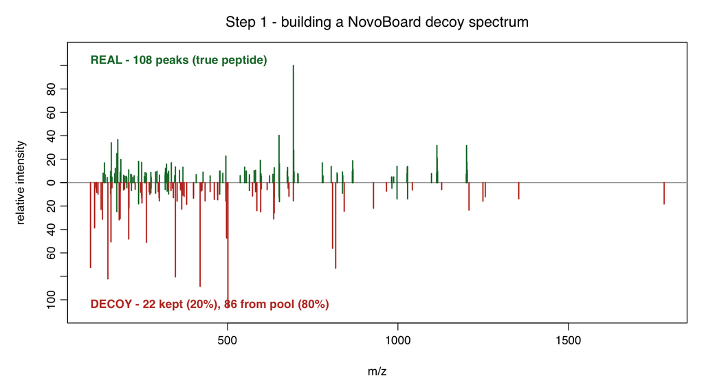

**Fig 1.** Ocelot spectrum (top) vs its decoy (bottom).

## 2. FRAC ≥ 0.8 is required — the leakage at 0.5 is severe

| quantity (ocelot) | FRAC 0.5 (leaky) | FRAC 0.8 (clean) |
| --- | --- | --- |
| decoy peptides hitting nr | 356 | 36 |
| decoy-vs-SwissProt hit rate | 0.284% | 0.030% |
| de novo pre-filter @1% (peptides kept) | 171 | 17,009 |
| conservatism (spectra/database null) | 12× | 1.3× |

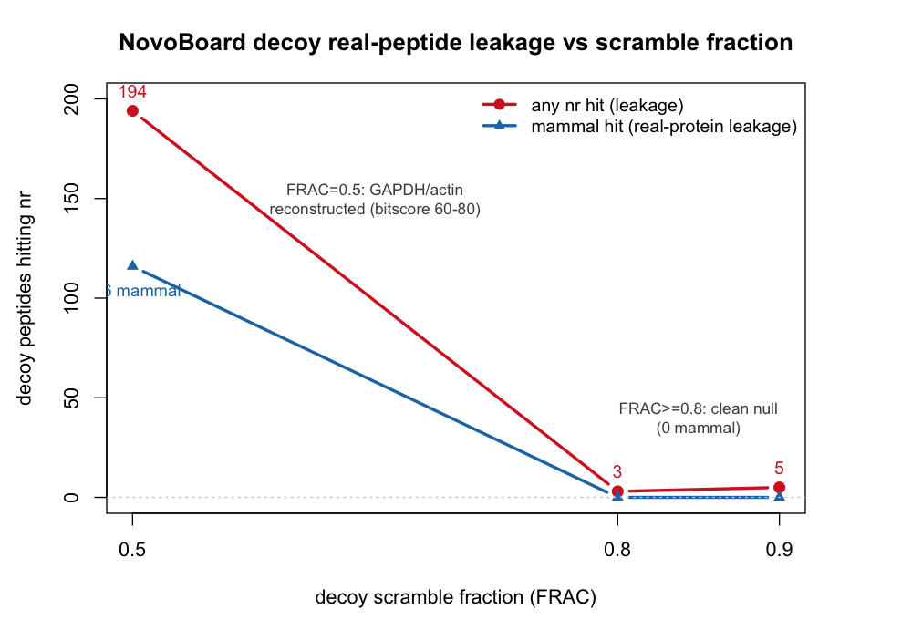

**Fig 2.** Peptide leakage into the null vs scramble fraction (HeLa entrapment).

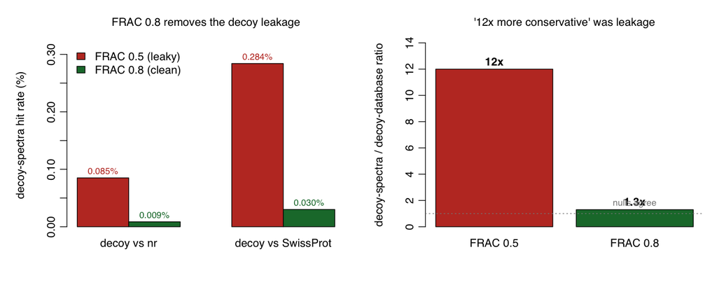

**Fig 3.** FRAC 0.8 removes the leakage (left) and the apparent "extra conservatism" of the spectra null (right).

## 3. Chance homology is ~zero, and the two decoy designs agree

Standard DIAMOND (E≤1) vs nr: real 9,852 hits (3.15%), decoy 36 (0.009%), global FDR 0.27% — all nr hits are real homology. The 4-way cross (SwissProt, standard) puts every null at the chance floor:

| query \ database | real DB (target) | reversed DB (decoy) |
| --- | --- | --- |
| **real** spectra | 14,337 (4.58%) | 73 (0.023%) |
| **decoy** spectra (f08) | 128 (0.030%) | 99 (0.023%) |

Decoy-spectra null (0.030%) ≈ decoy-database null (0.023%). **E-value-calibrated**, the two decoy designs **agree at both settings**: under **standard** both accept ~all 14,337 real hits at 1% FDR (decoy-spectra 14,337, decoy-database 14,336 — chance homology ~0); under **EXTRA** both recover ~18,000–22,000 (decoy-spectra 18,372, decoy-database 21,839) — EXTRA finds more, and the two nulls stay close. The chance-homology answer is essentially identical under either decoy design.

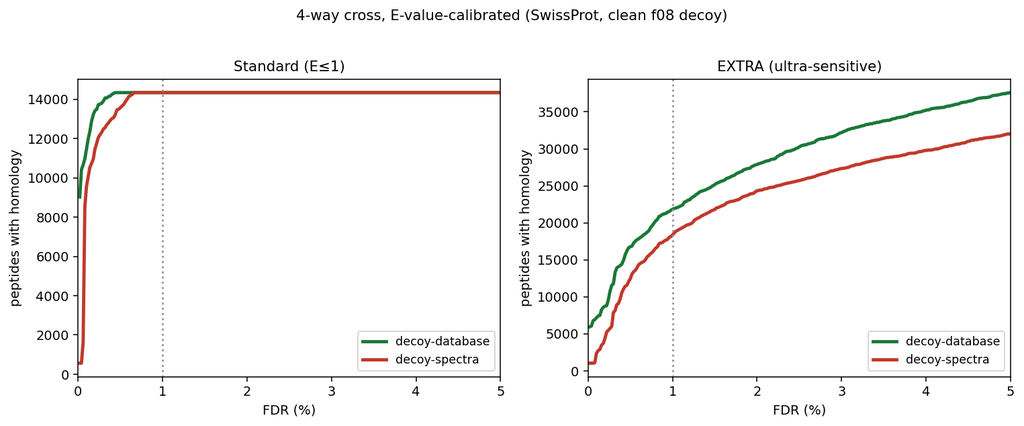

**Fig 4.** 4-way cross, recovery vs FDR, **E-value-calibrated** (SwissProt, clean f08), split by search. Standard (left): both nulls agree at ~14,337 (chance homology ~0). EXTRA (right): both nulls recover ~18–22k and stay close. (Recovery-vs-FDR frontier; the two decoy designs give the same answer.)

| Fig 4 values — recovery @ 1% FDR (SwissProt, E-value) | decoy-database null | decoy-spectra null |
| --- | --- | --- |
| Standard (E≤1) | 14,336 | 14,337 |
| EXTRA (ultra-sensitive) | 21,839 | 18,372 |

Standard accepts ~all 14,337 SwissProt hits (chance homology ~0); the two nulls are within 1 peptide of each other. Under EXTRA both recover more and stay close (within ~15%). These are SwissProt numbers (the cross needs a reversed DB); the species-ID recovery numbers are on nr (§4–5).

## 4. Scoring: bitscore vs E-value vs mokapot — and the role of peptide length

Raw bitscore is length-confounded (longer peptide → higher bitscore for the same match), so a global bitscore cut under-accepts short peptides. Three fixes, all tested on the EXTRA nr-Eukaryota search at 1% FDR (decoy-spectra null):

| scoring | peptides @ 1% FDR | note |
| --- | --- | --- |
| bitscore (raw) | 10,404 | length-confounded |
| **E-value** | 13,074 | length-normalized (works under EXTRA — `--min-score 1` only disables the E-value *filter*) |
| mokapot linear [bitscore + pep-length] | 14,706 | additive length term beats E-value |
| **mokapot linear [bitscore + E-value + length + %id]** | **19,556** | best homology-only score |
| mokapot GBT [bitscore + length] | 9,335 | **overfits** — worse than raw bitscore |
| mokapot GBT [bitscore + E-value + length + %id] | 12,352 | overfits — worse than linear |

**Length is handled best by a *linear* model with E-value, not a fancier one.** A linear mokapot using bitscore + E-value + length + %identity recovers 19,556 (+50% over E-value, +88% over raw bitscore). The non-linear gradient-boosted model **overfits the decoy** in the semi-supervised loop and does *worse* — which is exactly why Percolator/mokapot default to a linear model. "Use length optimally" = the linear model with the length-normalized E-value, not a deeper model.

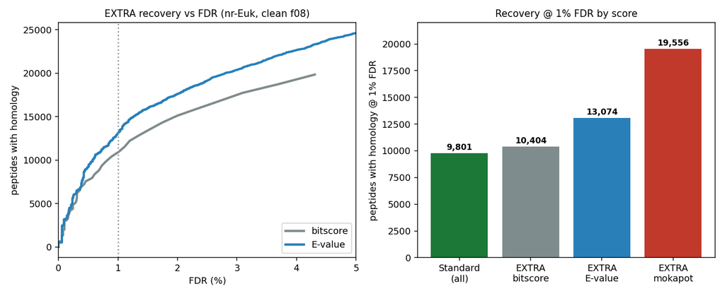

**Fig 5.** EXTRA recovery vs FDR by score (left, E-value above bitscore) and recovery at 1% FDR by score (right): bitscore 10,404 < E-value 13,074 < mokapot 19,556 (standard 9,801 shown for reference). All nr-Eukaryota, clean f08 decoy.

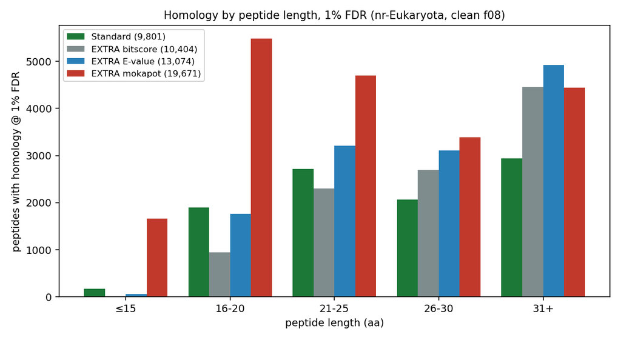

**Fig 6.** Confirmed homology by peptide length, four methods at 1% FDR (nr-Eukaryota, clean f08).

| peptide length (aa) | Standard | EXTRA bitscore | EXTRA E-value | EXTRA mokapot |
| --- | --- | --- | --- | --- |
| ≤15 | 168 | 11 | 60 | 1,661 |
| 16–20 | 1,903 | 946 | 1,769 | 5,488 |
| 21–25 | 2,717 | 2,306 | 3,214 | 4,700 |
| 26–30 | 2,070 | 2,691 | 3,109 | 3,384 |
| 31+ | 2,943 | 4,450 | 4,922 | 4,438 |
| **TOTAL** | **9,801** | **10,404** | **13,074** | **19,671** |

## 5. The clean decoy unlocks Casanovo confidence — a de novo pre-filter now works

A FRAC-0.8 decoy spectrum is mostly noise, so Casanovo sequences it with **low confidence** (median 0.55 vs real 0.72). That gap was absent at FRAC 0.5. With it, gating de novo peptides at 1% FDR *before* BLAST becomes viable:

| de novo pre-filter scoring | peptides kept @ 1% de novo FDR |
| --- | --- |
| Casanovo pep_score | 17,009 (171 on leaky f05) |
| mean Casanovo confidence | 31,744 |
| **mokapot** (score + conf + length) | **63,208** |

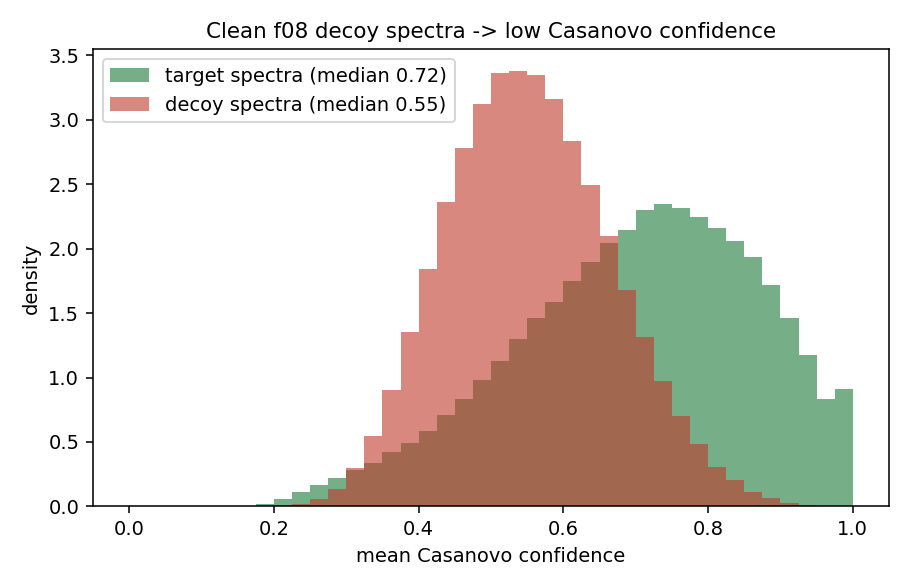

**Fig 7.** Mean Casanovo confidence: target spectra (0.72) vs clean f08 decoy spectra (0.55). This separation is what makes a de novo-level FDR and ML rescoring work.

## 6. What mokapot uses to discriminate — and how it differs by decoy type

Full **13-feature** mokapot, EXTRA, decoy-spectra null (standardized weights, sorted by |weight|); the decoy-database column is the 3-feature run on it (SwissProt, no traceback features available there):

| feature | what it is | decoy-spectra (full) | decoy-DB |
| --- | --- | --- | --- |
| **longest_run** | longest run of ≥0.9-confidence residues | **+2.21** | — |
| **n_hi** | # high-confidence residues that matched the reference | **+1.79** | — |
| E-value (−log10) | length-normalized homology significance | +0.91 | n/a |
| **pred_count** | log # spectra Casanovo de-novo-predicted to this *same* peptide (across the 9 runs) — prediction multiplicity, *not* a database PSM | **+0.70** | — |
| cterm | C-terminal residue confidence | +0.48 | — |
| CWI | confidence-weighted identity | +0.34 | — |
| nterm | N-terminal residue confidence | +0.22 | — |
| peptide length | nchar | +0.21 | −0.61 |
| mean_conf | mean per-residue confidence | −0.04 | +1.64 |
| %identity | alignment % identity | −0.11 | — |
| HCA | high-confidence agreement | −0.20 | — |
| min_conf | minimum per-residue confidence | −0.29 | — |
| bitscore | BLAST bit score | −1.03 | **+3.27** |
| **peptides @ 1% FDR** |  | **123,790** | **33,589** |

**The decoy-spectra null is confidence-led; the decoy-database null is homology-led.** With the full feature set the top two are **longest_run** (+2.21, longest high-confidence stretch) and **n_hi** (+1.79, confident residues that matched the reference) — both confidence-derived; mean_conf collapses to ~0 because the granular longest_run/n_hi/CWI carry its signal. **pred_count** (+0.70, the 5th-strongest feature) is a reproducibility signal — how many spectra Casanovo de-novo-predicted to the *same* peptide string across the 9 runs (real max 747 spectra; the clean decoy is almost all one-offs, max 113). A peptide called from hundreds of spectra is more credible than a singleton; the caveat is these are repeated *de novo predictions*, not database PSMs, so similar spectra can repeat the same error (correlated, not independent evidence) — which is why it helps modestly (+1.9% yield) and sits mid-pack rather than topping the list. The negative bitscore (−1.03) is a collinearity artifact (redundant once E-value/n_hi are in). The decoy-**database** null instead is led by raw **bitscore** (+3.27) with confidence demoted (+1.64) — there target and decoy are the same peptide vs different DBs, so confidence cancels. That is why mokapot helps most with the decoy-spectra null: it adds the de novo-confidence dimension the homology-only decoy-database cannot see.

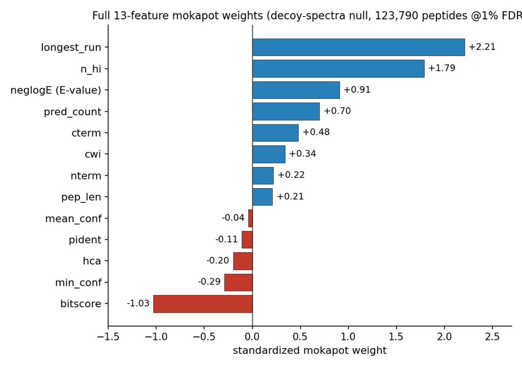

**Fig 8.** Full 13-feature mokapot weights (decoy-spectra null, 123,790 peptides @1% FDR). Confidence-derived features (longest_run, n_hi, terminal confidence, CWI) and de novo prediction count lead; bitscore is negative from collinearity with E-value/n_hi.

## 7. All FDR results side by side (exact peptide counts @ 1% FDR)

| FDR control / null | scoring | search | database | peptides @ 1% FDR |
| --- | --- | --- | --- | --- |
| De novo pre-filter (pre-BLAST) | Casanovo score | — | — | 17,009 |
| De novo pre-filter | mean confidence | — | — | 31,744 |
| De novo pre-filter | mokapot | — | — | 63,208 |
| Decoy-spectra homology | bitscore | Standard | nr-Euk | 9,801 (all hits) |
| Decoy-spectra homology | bitscore | EXTRA | nr-Euk | 10,404 |
| Decoy-spectra homology | E-value | EXTRA | nr-Euk | 13,074 |
| Decoy-spectra homology | mokapot (homology only) | EXTRA | nr-Euk | 19,556 |
| Decoy-spectra (full 13-feature) | **mokapot (conf + homology + n_hi/CWI/HCA + pred_count)** | EXTRA | nr-Euk | **123,790** |
| Decoy-database | bitscore (competition) | Standard | SwissProt | 14,337 (all hits) |
| Decoy-database | mokapot | EXTRA | SwissProt | 33,589 |

## 8. Ground-truth check: does the full-feature yield translate to correctness?

The 123,790 is a **yield at 1% decoy-spectra FDR** — it counts peptides whose real-spectrum-vs-noise separation clears the null. That is not the same as "123,790 verified-correct peptides." To test correctness we need ground truth, so we repeat the exercise on the **HeLa entrapment**, where a Sage database search (spectrum q≤0.01, ≥7 aa, I/L-normalized) gives an independent "this peptide is really in the sample" label. A de novo peptide is scored **correct** if its homology hit's query peptide is Sage-confirmed.

| FDR scoring (HeLa, nr-hit de novo peptides) | accepted @1% | Sage-confirmed precision | correct recovered |
| --- | --- | --- | --- |
| raw bitscore (accept all hits) | 5,068 | 42.4% (baseline) | 2,151 |
| mokapot, 8-feature | 4,090 | **49.4%** | 2,021 |
| mokapot, full 12-feature | 4,216 | 47.7% | 2,009 |

**Two honest conclusions.** (1) mokapot's accepted set *is* enriched for genuinely-correct peptides — precision rises from the 42.4% baseline to ~48–49%, so the model concentrates real homology, it does not just inflate counts. (2) But the **full 12-feature model does not beat the simpler one on ground-truth correctness**: it accepts ~3% more peptides (4,216 vs 4,090) at slightly *lower* precision (47.7% vs 49.4%) and recovers the same number of correct ones (2,009 vs 2,021). The granular confidence/traceback features (longest_run, n_hi, CWI…) raise *yield at fixed decoy-FDR* without adding *correctness* — on a saturated EXTRA decoy they let mokapot exploit the real-vs-noise confidence gap more aggressively, which moves the count but not the truth. So read 123,790 as "peptides that pass the de novo-error + homology FDR," and for a confident *species call* still layer a confidence/agreement threshold (de novo error drops to 21% at conf≥0.95) and LCA on top — the headline yield is a starting pool, not a verified-correct set.  
Caveat on the test: HeLa here is the *standard* search with the f05 decoy (the only setup where both Sage truth and a trainable null exist); ocelot's 123,790 is EXTRA + clean f08. The transferable lesson is the model comparison (full ≱ simple for correctness) and the precision floor (~48%, a lower bound since Sage truth is itself incomplete), not the absolute HeLa counts.

## 9. Compute cost: EXTRA is ~5× standard

| nr search (312,820 peptides, nr-Euk, 8×32-core array) | wall (parallel) | total compute | relative |
| --- | --- | --- | --- |
| Standard (E≤1) | ~14 min | ~44 core-hr | 1× |
| EXTRA (ultra-sensitive) | ~69 min | ~217 core-hr | **~5×** |

Standard as a single job on full nr is ~31 min. EXTRA's ~5× cost buys the +short-peptide homology and the confidence-driven mokapot gains.

**We BLAST all peptides, then threshold — not the 1% FDR set.** The query is all **312,820** Casanovo peptides (only structural filters: ≥7 aa, deduplicated; no confidence/FDR pre-filter), and the 1% FDR is applied to the hits *afterward*. So compute scales with the *full* peptide set, which is what makes EXTRA's ~5× sting on large cohorts.  
**The lever — a de novo pre-filter before BLAST.** Keeping only the peptides that pass 1% *de novo* FDR first (~17k by score, ~31k by confidence, ~63k by mokapot — §5) and BLASTing just those would cut the BLAST workload roughly **5–20×**. Trade-off: it discards low-confidence peptides before they are ever tested for homology — the de novo FDR controls "real spectrum vs noise," which is not the same as "has homology" — so it trades recall for speed plus an extra de novo-quality gate. This pre-filter is only viable on a **clean FRAC-0.8** decoy (on the leaky f05 it kept just 171 peptides; §2, §5). Default today: BLAST-all; switch to pre-filter when compute (large cohorts × EXTRA) is the bottleneck.

## 10. What limits a species call — and the recommended pipeline

| error mode | rate (HeLa entrapment) | control |
| --- | --- | --- |
| chance / spurious homology | ~0% (clean decoy) | decoy-spectra OR reversed-DB FDR (they agree) |
| **de novo sequence error** | 45% raw; 21% at conf≥0.95; 12% at conf≥0.99 | **confidence / mokapot** |
| species mis-assignment | 36% non-mammal by best-hit (conserved peptides) | **LCA over all hits** |

**Recommended pipeline.** (1) FRAC-0.8 decoy spectra. (2) EXTRA DIAMOND (or standard if compute-bound; EXTRA adds short peptides at ~5× cost). (3) FDR by a **linear mokapot** on E-value + length + bitscore + Casanovo confidence against the decoy-spectra null — this controls chance homology AND de novo error in one model, and the clean decoy makes the confidence term the strongest signal. Calibrate on E-value, never raw bitscore. (4) LCA over all hits for species. The reversed-database FDR is a valid, equivalent check on chance homology alone.

## 11. Exact settings & commands

**Decoy:** `denovo_decoy_gen.py <mzML> <out.mgf> 0.8 1337`. **DBs:** nr (Eukaryota via `--taxonlist 2759`); SwissProt `uniprot_sprot` + `uniprot_sprot_reversed`.

```
Standard: diamond blastp --evalue 1 --max-target-seqs 1 --ignore-warnings [--taxonlist 2759] \
  --outfmt 6 qseqid sseqid pident length evalue bitscore staxids --threads 32 -q QUERY -d DB -o OUT
EXTRA:    diamond blastp -b8.0 --matrix BLOSUM62 --ultra-sensitive -s2 --id2 1 \
  --short-query-ungapped-bitscore 1 --algo 0 --masking 0 --gapped-filter-evalue 0 --min-score 1 \
  --gapopen 6 --gapextend 2 --ignore-warnings [--taxonlist 2759] \
  --outfmt 6 qseqid sseqid pident length evalue bitscore staxids --max-target-seqs 1 --threads 32 -q QUERY -d DB -o OUT
# EXTRA still outputs a valid E-value per hit; --min-score 1 only disables the E-value FILTER.
```

Analysis artifacts: `/tmp/decoyval/` (composite_fdr.R, mokapot_*.py, run_mokapot.py); HPC `.../Ocelot_search_2/decoy_validation/decoy_f08/` and `/HeLa_entrapment/`.